# 16S rRNA gene processing and taxonomic assignment on DNA extracted from samples obtained in Oman in 2019

Source file: OM19_16S_taxa_assignment_DADA2_Silva138_Bayesian.Rmd

Daniel Nothaft

26 May 2020

# 1 Setup

Data processed using the packages [dada2](https://benjjneb.github.io/dada2/index.html) version 1.16.0.

Following [this tutorial](https://benjjneb.github.io/dada2/tutorial.html) for 16S gene data processing and [this tutorial](https://benjjneb.github.io/dada2/ITS_workflow.html)

Along with the `dada2` library, we also load the `ShortRead` and the `Biostrings` package, which will help to identify and count the primers present on the raw FASTQ sequence files.

```r
library(dada2); # processing sequence data
packageVersion("dada2")
library(ShortRead);
packageVersion("ShortRead") # determining primer reads
library(Biostrings);
packageVersion("Biostrings") # determining primer reads
library(tidyverse) # manipulating strings and data frames

# global knitting options for automatic saving of all plots as .png and .pdf. Also sets cache directory.
knitr::opts_chunk$set(
  dev = c("png", "pdf"), fig.keep = "all",
  dev.args = list(pdf = list(encoding = "WinAnsi", useDingbats = FALSE)),
  fig.path = file.path("fig_output/", paste0(gsub("\\.[Rr]md", "/", knitr::current_input()))),
  cache.path = file.path("cache/", paste0(gsub("\\.[Rr]md", "/", knitr::current_input())))
)
```

```
[1] '1.16.0'
[1] '1.46.0'
[1] '2.56.0'
```

Define where the fastq file are and check what the files are. These fastq files were previously demultiplexed.

```r
path <- "~/Desktop/Research/Oman_fieldwork/2019 info/Dan_Nothaft_16S_Data/demux-seqs/packers" # CHANGE ME to the directory containing the fastq files after unzipping.
list.files(path)
```

```
##  [1] "A108_S7_L001_R1_001.fastq.gz"  "A108_S7_L001_R2_001.fastq.gz"
##  [3] "A30_S5_L001_R1_001.fastq.gz"   "A30_S5_L001_R2_001.fastq.gz"
##  [5] "A41_S6_L001_R1_001.fastq.gz"   "A41_S6_L001_R2_001.fastq.gz"
##  [7] "B56_S2_L001_R1_001.fastq.gz"   "B56_S2_L001_R2_001.fastq.gz"
##  [9] "Blank_S9_L001_R1_001.fastq.gz" "Blank_S9_L001_R2_001.fastq.gz"
## [11] "D102_S3_L001_R1_001.fastq.gz"  "D102_S3_L001_R2_001.fastq.gz"
## [13] "D45_S4_L001_R1_001.fastq.gz"   "D45_S4_L001_R2_001.fastq.gz"
## [15] "filtered"                      "filtN"
```

Now we read in the names of the fastq files, and perform some string manipulation to get matched lists of the forward and reverse fastq files.

```r
# Forward and reverse fastq filenames have format: SAMPLENAME_R1_001.fastq and SAMPLENAME_R2_001.fastq
fnFs <- sort(list.files(path, pattern="_R1_001.fastq.gz", full.names = TRUE))
fnRs <- sort(list.files(path, pattern="_R2_001.fastq.gz", full.names = TRUE))
```

Extract sample names

```r
# Extract sample names, assuming filenames have format: SAMPLENAME_XXX.fastq
sample.names <- sapply(strsplit(basename(fnFs), "_S[[:digit:]]_L001"), `[`, 1)

sample.names
```

```
## [1] "A108"  "A30"   "A41"   "B56"   "Blank" "D102"  "D45"
```

# 2 Trimming sequences

## 2.1 Identify primers

The 515 (forward) (Parada) and 806R (reverse) (Apprill) primers ([EarthMicrobiome](https://earthmicrobiome.org/protocols-and-standards/16s/)) were used to amplify this dataset. We record the DNA sequences for those primers.

```r
FWD <- "GTGYCAGCMGCCGCGGTAA" # 515F (Parada)
REV <- "GGACTACNVGGGTWTCTAAT" # 806R (Apprill)
```

To ensure we have the right primers, and the correct orientation of the primers on the reads, we will verify the presence and orientation of these primers in the data.

```r
allOrients <- function(primer) {
    # Create all orientations of the input sequence
    require(Biostrings)
    dna <- DNAString(primer)  # The Biostrings works w/ DNAString objects rather than character vectors
    orients <- c(Forward = dna, Complement = complement(dna), Reverse = reverse(dna),
        RevComp = reverseComplement(dna))
    return(sapply(orients, toString))  # Convert back to character vector
}
FWD.orients <- allOrients(FWD)
REV.orients <- allOrients(REV)
FWD.orients
```

```
##               Forward            Complement               Reverse
## "GTGYCAGCMGCCGCGGTAA" "CACRGTCGKCGGCGCCATT" "AATGGCGCCGMCGACYGTG"
##               RevComp
## "TTACCGCGGCKGCTGRCAC"
```

The presence of ambiguous bases (Ns) in the sequencing reads makes accurate mapping of short primer sequences difficult. Next we are going to “pre-filter” the sequences just to remove those with Ns, but perform no other filtering.

```r
fnFs.filtN <- file.path(path, "filtN", basename(fnFs)) # Put N-filterd files in filtN/ subdirectory
fnRs.filtN <- file.path(path, "filtN", basename(fnRs))
filterAndTrim(fnFs, fnFs.filtN, fnRs, fnRs.filtN, maxN = 0, multithread = TRUE)
```

We are now ready to count the number of times the primers appear in the forward and reverse read, while considering all possible primer orientations. Identifying and counting the primers on one set of paired end FASTQ files is sufficient, assuming all the files were created using the same library preparation, so we’ll just process the first sample.

```r
primerHits <- function(primer, fn) { # Counts number of reads in which the primer is found
    nhits <- vcountPattern(primer, sread(readFastq(fn)), fixed = FALSE)
    return(sum(nhits > 0))
}
rbind(FWD.ForwardReads = sapply(FWD.orients, primerHits, fn=fnFs.filtN[[1]]),
      FWD.ReverseReads = sapply(FWD.orients, primerHits, fn=fnRs.filtN[[1]]),
      REV.ForwardReads = sapply(REV.orients, primerHits, fn=fnFs.filtN[[1]]),
      REV.ReverseReads = sapply(REV.orients, primerHits, fn=fnRs.filtN[[1]]))
```

```
##                  Forward Complement Reverse RevComp
## FWD.ForwardReads  105595          0       0      14
## FWD.ReverseReads      16          0       0   87978
## REV.ForwardReads      16          0       0   98385
## REV.ReverseReads  105004          0       0      14
```

As expected, the FWD primer is found in the forward reads in its forward orientation, and in the reverse reads in its reverse-complement orientation. Similarly, the REV primer is found with its expected orientations. We will remove the primers later when we truncate lower quality reads. So now let’s inspect read quality profiles.

## 2.2 Inspect read quality profiles

We start by visualizing the quality profiles of the forward reads:

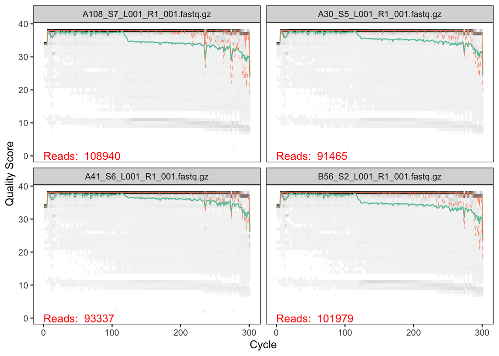

```r
plotQualityProfile(fnFs[1:4])
```

In gray-scale is a heat map of the frequency of each quality score at each base position. The difference between a quality score of 40 and a quality score of 20 is an expected error rate of 1 in 10,000 vs 1 in 100 ([Phred](https://en.wikipedia.org/wiki/Phred_quality_score)). The median quality score at each position is shown by the green line, and the quartiles of the quality score distribution by the orange lines. The red line shows the scaled proportion of reads that extend to at least that position (this is more useful for other sequencing technologies, as Illumina reads are typically all the same lenghth, hence the flat red line).

The forward reads are good quality. DADA2 generally advises trimming the last few nucleotides to avoid less well-controlled errors that can arise there. We will truncate the forward reads at position 260.

Now we visualize the quality profile of the reverse reads:

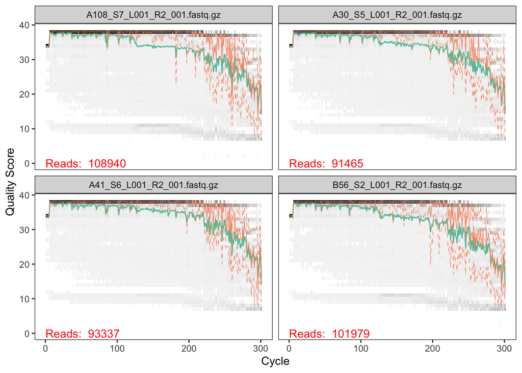

```r
plotQualityProfile(fnRs[1:4])
```

The reverse reads also look to be of generally good quality, but the quality decreases more with cycle number than the forward reads. This is common. Thus, we will truncate the reverse reads at position 200, which is a bit shorter than the forward read truncation.

The chosen truncation lengths seem pretty conservative. Through several iterations of truncation lengths, it was determined that keeping more reads, particularly for reverse reads, led to ~50% loss of reads at the DADA2 chimera filtering step. With the truncation lengths selected here, ~85% of reads are retained at this chimera filtering step, presumably due to higher overall read quality achieve by truncating lower quality reads in the reverse cycle.

## 2.3 Filter reads

Make folder for filtered reads and rename files

```r
# Place filtered files in filtered/ subdirectory
filtFs <- file.path(path, "filtered", paste0(sample.names, "_F_filt.fastq.gz"))
filtRs <- file.path(path, "filtered", paste0(sample.names, "_R_filt.fastq.gz"))
```

Filter arguments:

1. truncLen sets the length at which reads should be truncated which is also the minimum length of a read required to pass the filter for the (forward,reverse) reads, default is 0 and no reads are truncated.
2. maxN sets the maximum number of N reads allowed in a sequence, by default dada2 doesn’t allow any Ns
3. maxEE sets the maximum number of expected errors that are accepted before a read is tossed. default is infinity.
4. truncQ truncates the read once a quality score at or below truncQ is hit.
5. rm.phix discards reads that match the phiX genome, default is TRUE
6. matchIDs default is FALSE which assumes that paired end reads are in matching order, TRUE only outputs reads where both forward and reverse can be found and matched.
7. compress default is TRUE if fastq files are gzipped
8. multithread allows for parallelization, default is FALSE

We’ll use standard filtering parameters: maxN=0 (DADA2 requires no Ns), truncQ=2, rm.phix=TRUE and maxEE=2. The maxEE parameter sets the maximum number of “expected errors” allowed in a read, which is a better filter than simply averaging quality scores. (https://academic.oup.com/bioinformatics/article/31/21/3476/194979)

We lose a considerable amount of reads (~20%) due to trimming, but that’s OK.

```r
# filtering out primer length using trimLeft argument
out <- filterAndTrim(fnFs, filtFs, fnRs, filtRs, truncLen=c(260, 200), trimLeft = c((str_length(FWD)), (str_length(REV))),
              maxN=0, maxEE=c(2,2), truncQ=2, rm.phix=TRUE,
              compress=TRUE, multithread=TRUE) # On Windows set multithread=FALSE
head(out)
```

```
##                               reads.in reads.out
## A108_S7_L001_R1_001.fastq.gz    108940     90063
## A30_S5_L001_R1_001.fastq.gz      91465     79493
## A41_S6_L001_R1_001.fastq.gz      93337     84810
## B56_S2_L001_R1_001.fastq.gz     101979     85193
## Blank_S9_L001_R1_001.fastq.gz    23224       101
## D102_S3_L001_R1_001.fastq.gz    109991     65765
```

## 2.4 Check Primer removal

As a sanity check, we will count the presence of primers in the first filtered sample:

```r
rbind(FWD.ForwardReads = sapply(FWD.orients, primerHits, fn = filtFs[[1]]), FWD.ReverseReads = sapply(FWD.orients,
    primerHits, fn = filtRs[[1]]), REV.ForwardReads = sapply(REV.orients, primerHits,
    fn = filtFs[[1]]), REV.ReverseReads = sapply(REV.orients, primerHits, fn = filtRs[[1]]))
```

```
                 Forward Complement Reverse RevComp
FWD.ForwardReads       0          0       0       0
FWD.ReverseReads       0          0       0       0
REV.ForwardReads       0          0       0       7
REV.ReverseReads       5          0       0       0
```

Success! The vast majority of primer sequences have been removed.

# 3 Learn errors

The DADA2 algorithm makes use of a parametric error model (err) and every amplicon dataset has a different set of error rates. The learnErrors method learns this error model from the data, by alternating estimation of the error rates and inference of sample composition until they converge on a jointly consistent solution. As in many machine-learning problems, the algorithm must begin with an initial guess, for which the maximum possible error rates in this data are used (the error rates if only the most abundant sequence is correct and all the rest are errors).

```r
errF <- learnErrors(filtFs, multithread=TRUE)
```

```
## 106451628 total bases in 441708 reads from 7 samples will be used for learning the error rates.
```

Reverse:

```r
errR <- learnErrors(filtRs, multithread=TRUE)
```

```
## 79507440 total bases in 441708 reads from 7 samples will be used for learning the error rates.
```

Visualize estimated error rates.

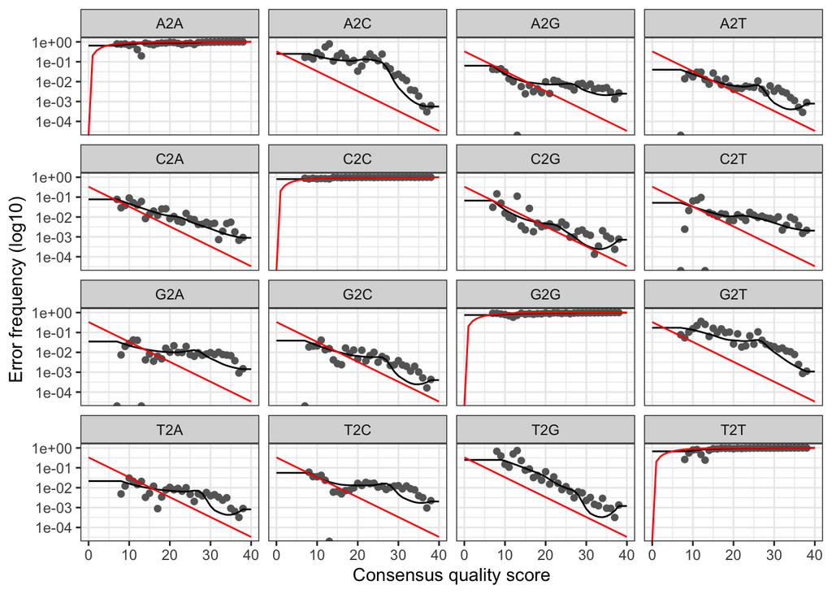

```r
plotErrors(errF, nominalQ=TRUE)
```

The error rates for each possible transition (A→C, A→G, …) are shown. Points are the observed error rates for each consensus quality score. The black line shows the estimated error rates after convergence of the machine-learning algorithm. The red line shows the error rates expected under the nominal definition of the Q-score. Here the estimated error rates (black line) are a good fit to the observed rates (points), and the error rates drop with increased quality as expected. Everything looks reasonable and we proceed with confidence.

# 4 Dereplication

Dereplication combines all identical sequencing reads into into “unique sequences” with a corresponding “abundance” equal to the number of reads with that unique sequence. Dereplication substantially reduces computation time by eliminating redundant comparisons.

Dereplication in the DADA2 pipeline has one crucial addition from other pipelines: DADA2 retains a summary of the quality information associated with each unique sequence. The consensus quality profile of a unique sequence is the average of the positional qualities from the dereplicated reads. These quality profiles inform the error model of the subsequent sample inference step, significantly increasing DADA2’s accuracy.

```r
derepFs <- derepFastq(filtFs, verbose=TRUE)
derepRs <- derepFastq(filtRs, verbose=TRUE)
# Name the derep-class objects by the sample names
names(derepFs) <- sample.names
names(derepRs) <- sample.names
```

# 5 Sample inference

We are now ready to apply [the core sample inference algorithm](https://www.nature.com/articles/nmeth.3869#methods) to the dereplicated data.

```r
dadaFs <- dada(derepFs, err=errF, multithread=TRUE)
```

```
## Sample 1 - 90063 reads in 12260 unique sequences.
## Sample 2 - 79493 reads in 18917 unique sequences.
## Sample 3 - 84810 reads in 23766 unique sequences.
## Sample 4 - 85193 reads in 8061 unique sequences.
## Sample 5 - 101 reads in 38 unique sequences.
## Sample 6 - 65765 reads in 12229 unique sequences.
## Sample 7 - 36283 reads in 5074 unique sequences.
```

```r
dadaRs <- dada(derepRs, err=errR, multithread=TRUE)
```

```
## Sample 1 - 90063 reads in 11008 unique sequences.
## Sample 2 - 79493 reads in 16613 unique sequences.
## Sample 3 - 84810 reads in 20151 unique sequences.
## Sample 4 - 85193 reads in 8360 unique sequences.
## Sample 5 - 101 reads in 43 unique sequences.
## Sample 6 - 65765 reads in 10445 unique sequences.
## Sample 7 - 36283 reads in 4411 unique sequences.
```

Inspecting the returned dada-class object:

```r
dadaFs[[1]]
```

```
## dada-class: object describing DADA2 denoising results
## 149 sequence variants were inferred from 12260 input unique sequences.
## Key parameters: OMEGA_A = 1e-40, OMEGA_C = 1e-40, BAND_SIZE = 16
```

# 6 Merging paired ends

We now merge the forward and reverse reads together to obtain the full denoised sequences. Merging is performed by aligning the denoised forward reads with the reverse-complement of the corresponding denoised reverse reads, and then constructing the merged “contig” sequences. By default, merged sequences are only output if the forward and reverse reads overlap by at least 12 bases, and are identical to each other in the overlap region.

```r
mergers <- mergePairs(dadaFs, derepFs, dadaRs, derepRs, verbose=TRUE)
```

```
## 87030 paired-reads (in 141 unique pairings) successfully merged out of 89337 (in 333 pairings) input.
```

```
## 74453 paired-reads (in 565 unique pairings) successfully merged out of 76763 (in 1195 pairings) input.
```

```
## 78317 paired-reads (in 458 unique pairings) successfully merged out of 82439 (in 1544 pairings) input.
```

```
## 84328 paired-reads (in 135 unique pairings) successfully merged out of 84917 (in 302 pairings) input.
```

```
## 92 paired-reads (in 3 unique pairings) successfully merged out of 92 (in 3 pairings) input.
```

```
## 62288 paired-reads (in 199 unique pairings) successfully merged out of 64944 (in 523 pairings) input.
```

```
## 35199 paired-reads (in 100 unique pairings) successfully merged out of 35835 (in 195 pairings) input.
```

```r
# Inspect the merger data.frame from the first sample
head(mergers[[1]])
```

|  | sequence | abundance | forward | reverse | nmatch | nmismatch | nindel | prefer | accept |
| --- | --- | --- | --- | --- | --- | --- | --- | --- | --- |
| 1 | GACAGAGGTGGCGAGCGTTGTTCGGAATTACTGGGCTTAAAGGGCGCGTAGGCGGTAGTG…… | 69366 | 1 | 1 | 168 | 0 | 0 | 1 | TRUE |
| 2 | TACGTAGGGTGCGAGCGTTAATCGGAATTACTGGGCGTAAAGCGTGCGCAGGCGGTTTTG…… | 2477 | 2 | 2 | 168 | 0 | 0 | 2 | TRUE |
| 3 | TACGGAGGGTGCAAGCGTTACCCGGATTTACTGGGTGTAAAGGGCGTGTAGGCGGTCTCT…… | 1787 | 3 | 3 | 168 | 0 | 0 | 1 | TRUE |
| 4 | TACGTAGGGTGCAAGCGTTGTCCGGAATCACTGGGTGTAAAGGGAGCGCAGGCGGGTTGG…… | 929 | 4 | 4 | 168 | 0 | 0 | 2 | TRUE |
| 5 | TACGTAGGGGGCGAGCGTTGTCCGGAATTACTGGGCGTAAAGGGCGAGTAGGCGGTTTAA…… | 752 | 7 | 5 | 168 | 0 | 0 | 2 | TRUE |
| 6 | TACGAAGGGTGCAAGCGTTACTCGGAATTACTGGGCGTAAAGCGTGCGTAGGCGGTTTGT…… | 659 | 5 | 6 | 168 | 0 | 0 | 2 | TRUE |

The mergers object is a list of data.frames from each sample. Each data.frame contains the merged sequence, its abundance, and the indices of the forward and reverse sequence variants that were merged. Paired reads that did not exactly overlap were removed by mergePairs, further reducing spurious output.

# 7 Construct sequence table

We can now construct an amplicon sequence variant table (ASV) table, a higher-resolution version of the OTU table produced by traditional methods.

```r
# create sequence table
seqtab <- makeSequenceTable(mergers)
# show dimenions of sequence table
dim(seqtab)
```

```
## [1]    7 1282
```

```r
# Inspect distribution of sequence lengths
table(nchar(getSequences(seqtab)))
```

```
##
##  241  251  252  253  254  255  256  280  288  305
##    4    2    2 1209   52    7    2    2    1    1
```

# 8 Remove chimeras

The core dada method corrects substitution and indel errors, but chimeras remain. Fortunately, the accuracy of the sequence variants after denoising makes identifying chimeras simpler than it is when dealing with fuzzy OTUs. Chimeric sequences are identified if they can be exactly reconstructed by combining a left-segment and a right-segment from two more abundant “parent” sequences.

It is common for chimeric sequences to be a majority (even large majority) of the total number of unique sequence variants inferred by the dada(…) algorithm, but they should not be a majority of the sequencing reads. That is, there may be many chimeras, but they are relatively low abundance.

```r
# remove chimeras
seqtab.nochim <- removeBimeraDenovo(seqtab, method="consensus", multithread=TRUE, verbose=TRUE)
```

```
## Identified 749 bimeras out of 1282 input sequences.
```

```r
# show dimensions of resulting dataframe
dim(seqtab.nochim)
```

```
## [1]   7 533
```

This double checks that you didn’t just toss most of your reads, if this percentage is low it means that few of your total reads remain and then you need to go back. In this dataset, chimeras account for about 15% of the merged sequence reads, which is decent.

```r
sum(seqtab.nochim)/sum(seqtab)
```

```
## [1] 0.8354734
```

# 9 Check pipeline filtering by step

Hopefully you kept most of the input reads, and there shouldn’t be one step where most of the reads were lost.

```r
getN <- function(x) sum(getUniques(x))
track <- cbind(out, sapply(dadaFs, getN), sapply(dadaRs, getN), sapply(mergers, getN), rowSums(seqtab.nochim))
# If processing a single sample, remove the sapply calls: e.g. replace sapply(dadaFs, getN) with getN(dadaFs)
colnames(track) <- c("input", "filtered", "denoisedF", "denoisedR", "merged", "nonchim")
rownames(track) <- sample.names
head(track)
```

```
##        input filtered denoisedF denoisedR merged nonchim
## A108  108940    90063     89586     89634  87030   83732
## A30    91465    79493     77409     77845  74453   65379
## A41    93337    84810     82982     83584  78317   61900
## B56   101979    85193     84978     85091  84328   73244
## Blank  23224      101        95        92     92      92
## D102  109991    65765     65142     65392  62288   41454
```

Looks good! We kept the majority of our raw reads, and there is no over-large drop associated with any single step.

# 10 Assign taxonomy

It is common at this point, especially in 16S/18S/ITS amplicon sequencing, to assign taxonomy to the sequence variants. The DADA2 package provides a native implementation of the naive Bayesian classifier method for this purpose. The assignTaxonomy function takes as input a set of sequences to be classified and a training set of reference sequences with known taxonomy, and outputs taxonomic assignments with at least minBoot bootstrap confidence.

Here, we use the Silva 138 training set.

```r
taxa_Silva <- assignTaxonomy(seqtab.nochim, "~/Desktop/Boulder/2018_fall/molecular_methods_ebio/Molecular-Methods/dada2/silva_nr_v138_train_set.fa.gz", multithread=TRUE)
```

Extensions: The dada2 package also implements a method to make species level assignments based on exact matching between ASVs and sequenced reference strains. Recent analysis suggests that exact matching (or 100% identity) is the only appropriate way to assign species to 16S gene fragments.

```r
taxa_Silva <- addSpecies(taxa_Silva, "/Users/melo.d/Desktop/Boulder/2018_fall/molecular_methods_ebio/Molecular-Methods/dada2/silva_species_assignment_v138.fa.gz")
```

Let’s inspect the taxonomic assignments:

```r
taxa.print <- taxa_Silva # Removing sequence rownames for display only
rownames(taxa.print) <- NULL
head(taxa.print)
```

```
##      Kingdom    Phylum           Class                    Order
## [1,] "Bacteria" "Nitrospirota"   "Thermodesulfovibrionia" NA
## [2,] "Bacteria" "Proteobacteria" "Gammaproteobacteria"    "Xanthomonadales"
## [3,] "Bacteria" "Proteobacteria" "Alphaproteobacteria"    "Parvibaculales"
## [4,] "Bacteria" "Proteobacteria" "Gammaproteobacteria"    "Burkholderiales"
## [5,] "Bacteria" "Nitrospirota"   "Thermodesulfovibrionia" NA
## [6,] "Bacteria" "GAL15"          NA                       NA
##      Family             Genus          Species
## [1,] NA                 NA             NA
## [2,] "Xanthomonadaceae" "Silanimonas"  NA
## [3,] "Parvibaculaceae"  "Parvibaculum" "lavamentivorans"
## [4,] "Comamonadaceae"   "Brachymonas"  NA
## [5,] NA                 NA             NA
## [6,] NA                 NA             NA
```

# 11 Export output tables

(courtesy of Mike Lee aka Astrobio Mike)

```r
 # giving our seq headers more manageable names (ASV_1, ASV_2...)
asv_seqs <- colnames(seqtab.nochim)
asv_headers <- vector(dim(seqtab.nochim)[2], mode="character")

for (i in 1:dim(seqtab.nochim)[2]) {
  asv_headers[i] <- paste(">ASV", i, sep="_")
}

  # making and writing out a fasta of our final ASV seqs:
asv_fasta <- c(rbind(asv_headers, asv_seqs))
write(asv_fasta, file = format(Sys.Date(), "data_output/%Y%m%d_ASVs_Silva_OM19_Silva138_Bayes_packers.fa"))

  # count table:
asv_tab <- t(seqtab.nochim)
row.names(asv_tab) <- sub(">", "", asv_headers)
write.table(asv_tab, file = format(Sys.Date(), "data_output/%Y%m%d_ASVs_counts_OM19_Silva138_Bayes_packers.txt"), sep="\t", quote=F)

  # tax table:
asv_tax <- taxa_Silva
row.names(asv_tax) <- sub(">", "", asv_headers)
write.table(asv_tax, file = format(Sys.Date(), "data_output/%Y%m%d_ASVs_taxonomy_OM19_Silva138_Bayes_packers.txt"), sep="\t", quote=F)
```

DBN making these taxa tables in format mctoolsr will accept

```r
asv_tax_one_string <- as.data.frame(asv_tax) # make taxa table a dataframe

# make a single string out of all the taxa levels
asv_tax_one_string$taxonomy <- paste0("k__", asv_tax_one_string$Kingdom, "; p__", asv_tax_one_string$Phylum, "; c__", asv_tax_one_string$Class, "; o__", asv_tax_one_string$Order, "; f__", asv_tax_one_string$Family, "; g__", asv_tax_one_string$Genus, "; s__", asv_tax_one_string$Species)

asv_IDs_tax <- as.data.frame(rownames(asv_tax_one_string)) # make a dataframe of ASV ID's
colnames(asv_IDs_tax) <- c("#OTU ID") # Add ASV ID's to taxa table as a row

asv_tax_one_string <- bind_cols(asv_IDs_tax,  asv_tax_one_string) # adding together data frames containing ASV ID's and the single string taxonomic classification

asv_tax_one_string <- asv_tax_one_string %>% select(-Kingdom, -Phylum, -Class, -Order, -Family, -Genus, -Species) # remove rows containing taxonomic classification by individual taxonomic levels

asv_tab_df <- as.data.frame(asv_tab) # convert table of ASV counts to dataframe

asv_IDs_asv_tab <- as.data.frame(rownames(asv_tab_df)) # make dataframe of ASV ID's
colnames(asv_IDs_asv_tab) <- ("#OTU ID") # Name column containing ASV ID's

asv_tab_df <- bind_cols(asv_IDs_asv_tab,  asv_tab_df) # Add together dataframes of ASV ID's and ASV counts

tax_tab_for_mctoolsr_Silva <- asv_tab_df %>% right_join(asv_tax_one_string, by = '#OTU ID') # join data frames of taxonomic classifications and counts

head(tax_tab_for_mctoolsr_Silva) # print first few rows
```

|  | #OTU ID | A108 | A30 | A41 | B56 | Blank | D102 | D45 | taxonomy |
| --- | --- | --- | --- | --- | --- | --- | --- | --- | --- |
| 1 | ASV_1 | 69366 | 332 | 20758 | 8577 | 0 | 10239 | 21480 | k__Bacteria; p__Nitrospirota; c__Thermodesulfovibrionia; o__NA; f__NA; g__NA; s__NA |
| 2 | ASV_2 | 659 | 1178 | 47 | 58881 | 0 | 472 | 54 | k__Bacteria; p__Proteobacteria; c__Gammaproteobacteria; o__Xanthomonadales; f__Xanthomonadaceae; g__Silanimonas; s__NA |
| 3 | ASV_3 | 80 | 23828 | 668 | 0 | 0 | 9 | 69 | k__Bacteria; p__Proteobacteria; c__Alphaproteobacteria; o__Parvibaculales; f__Parvibaculaceae; g__Parvibaculum; s__lavamentivorans |
| 4 | ASV_4 | 2477 | 514 | 14806 | 0 | 0 | 28 | 15 | k__Bacteria; p__Proteobacteria; c__Gammaproteobacteria; o__Burkholderiales; f__Comamonadaceae; g__Brachymonas; s__NA |
| 5 | ASV_5 | 0 | 49 | 698 | 0 | 0 | 9175 | 141 | k__Bacteria; p__Nitrospirota; c__Thermodesulfovibrionia; o__NA; f__NA; g__NA; s__NA |
| 6 | ASV_6 | 0 | 19 | 0 | 0 | 0 | 10002 | 0 | k__Bacteria; p__GAL15; c__NA; o__NA; f__NA; g__NA; s__NA |

```r
write.table(tax_tab_for_mctoolsr_Silva, file = format(Sys.Date(), "data_output/%Y%m%d_tax_tab_DADA2_mctoolsr_OM19_Silva138_Bayes_packers.txt"), row.names = FALSE, sep="\t", quote=F) # write a .txt file of the taxa table
```